# Forecasting in R

Jemma Nelson, written for BH Analytics, LLC

# Forecasting in R

In this tutorial, we’ll examine the tools for forecasting in R, or modeling with time data.

We’ll refer often to the excellent online text [“Forecasting: Principles and Practice” by Rob Hyndman.](https://otexts.com/fpp2/)

# Packages needed

For this module, you will need the following packages:

```r
# install.packages("tidyverse","lubridate","forecast","tsibble","tsbox","fpp2","xts","urca")
```

# Forecasting and prediction

Forecasting is predicting the future, given past data.

Forecasts are often sub-categorized as “short-,” “medium-,” and “long-term,” depending on how far out the forecasts reach, and whether they concentrate on topics such as scheduling, resource management, or strategic planning.

In forecasting the data is a **time series,** with some time component that has a **frequency** and may have **seasonality** or **cycles.** Models used for forecasting include *simple methods,* *linear models* and *ARIMA.*

# What is a forecast?

A forecast is a prediction of possible future values. It is often accompanied by a **prediction interval** giving a range of probable values for the variable. A **forecast** is the average value of a **forecast distribution,** which is the probability distribution of the future of our random variable, given our past data.

# Time series

A time series object in `R` is a particular class that represents a vector of measurements, along with information about when those measurements were recorded.

The core time series object in R is the `ts` object, and R comes bundled with several built in time series data sets.

When you plot a time series, R defaults to a line plot.

```r
typeof(lynx) #numeric values
```

```
## [1] "double"
```

```r
lynx
```

```
## Time Series:
## Start = 1821
## End = 1934
## Frequency = 1
##   [1]  269  321  585  871 1475 2821 3928 5943 4950 2577  523   98  184  279  409 2285 2685 3409 1824  409  151   45   68  213  546 1033 2129 2536  957
##  [30]  361  377  225  360  731 1638 2725 2871 2119  684  299  236  245  552 1623 3311 6721 4254  687  255  473  358  784 1594 1676 2251 1426  756  299
##  [59]  201  229  469  736 2042 2811 4431 2511  389   73   39   49   59  188  377 1292 4031 3495  587  105  153  387  758 1307 3465 6991 6313 3794 1836
##  [88]  345  382  808 1388 2713 3800 3091 2985 3790  674   81   80  108  229  399 1132 2432 3574 2935 1537  529  485  662 1000 1590 2657 3396
```

```r
str(lynx)
```

```
##  Time-Series [1:114] from 1821 to 1934: 269 321 585 871 1475 ...
```

```r
class(lynx) #Annual Canadian Lynx trappings 1821-1934
```

```
## [1] "ts"
```

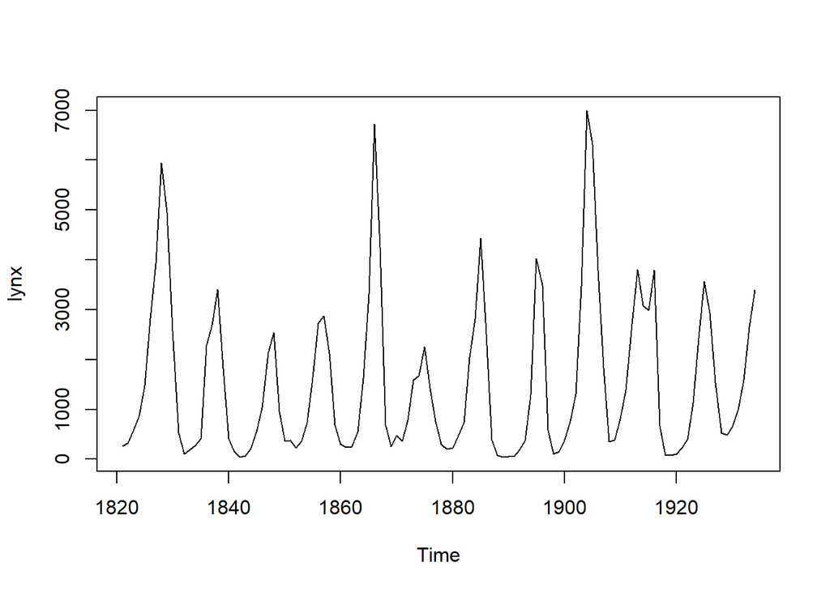

```r
plot(lynx)
```

```r
class(nhtemp) #Average Yearly Temperatures in New Haven
```

```
## [1] "ts"
```

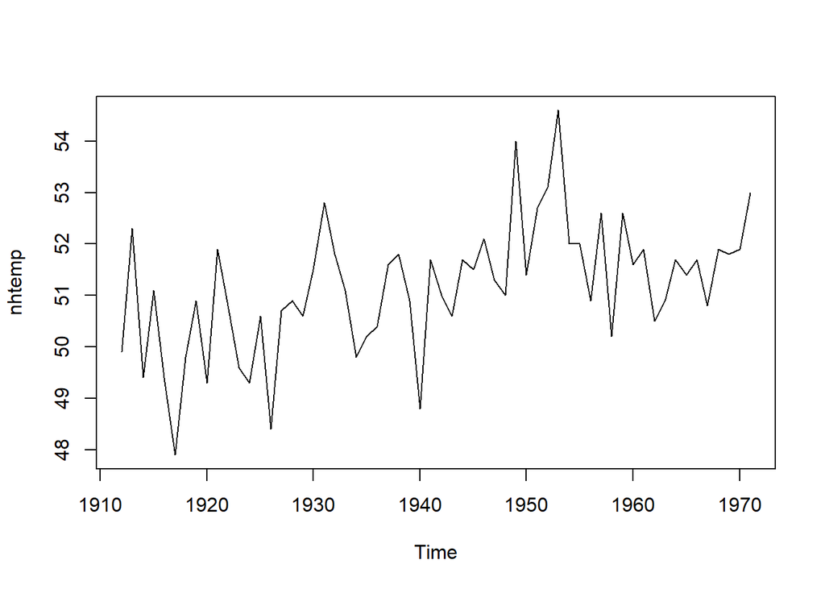

```r
plot(nhtemp)
```

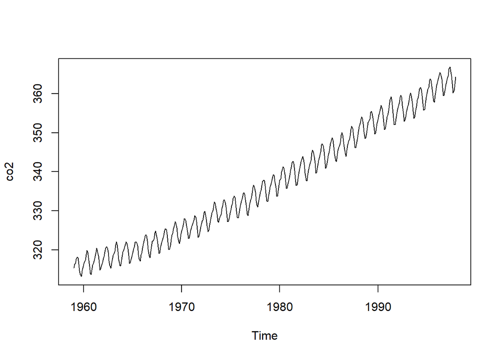

```r
plot(co2) #Mauna Loa Atmospheric CO2 Concentration
```

# Constructing a time series

You can construct a time series by providing your observations as well as a start time and frequency.

| Frequency | Value |
| --- | --- |
| Annual | 1 |
| Quarterly | 4 |
| Monthly | 12 |
| Weekly | 52 |

```r
x <- rnorm(10) #some random numbers from a standard normal distribution
y <- ts(x,start=2000) #made into a time series starting at year 2000
# default frequency is yearly (1)
y
```

```
## Time Series:
## Start = 2000
## End = 2009
## Frequency = 1
##  [1] -1.66258407 -0.80314823  0.05559540  0.38724832  0.01358477  0.21668600 -0.20726553  1.15701342 -1.09885072  1.90204287
```

```r
class(y)
```

```
## [1] "ts"
```

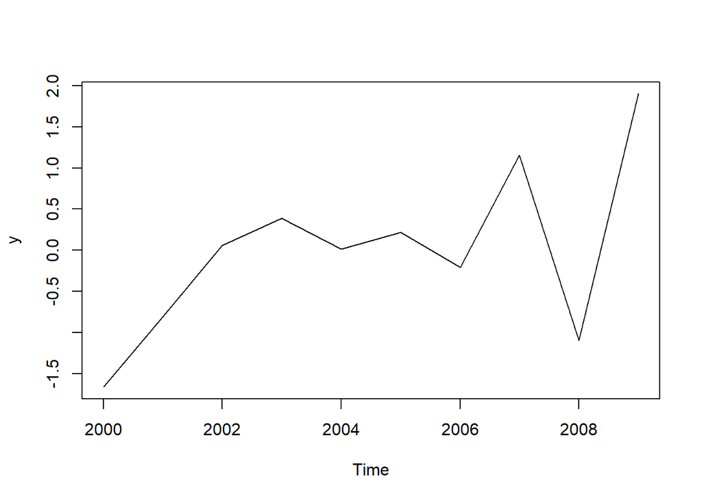

```r
plot(y)
```

```r
ymon <- ts(x,start = 2018, frequency = 12)
ymon
```

```
##              Jan         Feb         Mar         Apr         May         Jun         Jul         Aug         Sep         Oct
## 2018 -1.66258407 -0.80314823  0.05559540  0.38724832  0.01358477  0.21668600 -0.20726553  1.15701342 -1.09885072  1.90204287
```

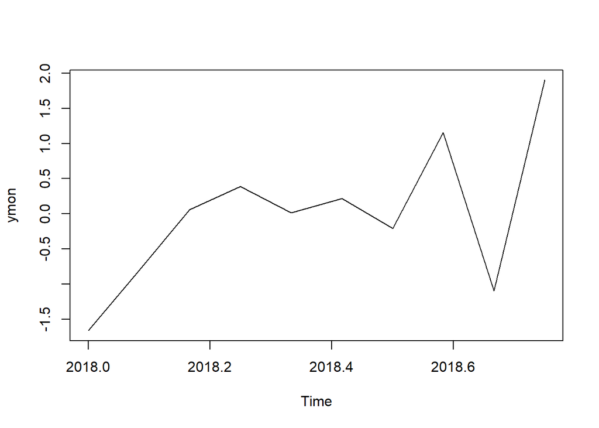

```r
plot(ymon)
```

# EX1. Make a time series

> Make a time series out of the mtcars mpg column. Give it a start time of 2018 and a frequency of 12. Plot it (it will essentially be “noise”)

```
## [1] 21.0 21.0 22.8 21.4 18.7 18.1
```

```
##       Jan  Feb  Mar  Apr  May  Jun  Jul  Aug  Sep  Oct  Nov  Dec
## 2018 21.0 21.0 22.8 21.4 18.7 18.1 14.3 24.4 22.8 19.2 17.8 16.4
## 2019 17.3 15.2 10.4 10.4 14.7 32.4 30.4 33.9 21.5 15.5 15.2 13.3
## 2020 19.2 27.3 26.0 30.4 15.8 19.7 15.0 21.4
```

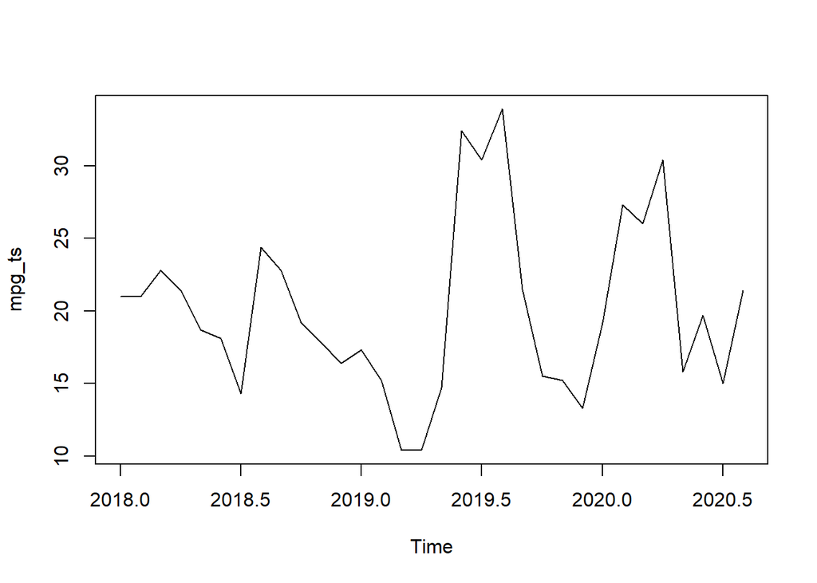

# Multiple time formats

For more functionality, there are other time series objects. In fact, there are many competing formats, such as ‘xts,’ ‘zoo,’ and others.

The built-in `ts` object works best for regular time series data on a yearly, quarterly or monthly frequency. `xts` extends this functionality to include irregular frequency and the possibility of using time formats.

One notable modern variant of the time series is the `tsibble.` A tsibble is a time series tibble. It looks like a data frame, with a datetime column marked as an *index.*

Here, we’ll convert our time series to a `xts` and a `tsibble` using `as.xts()` and `as_tsibble().`

In the conversion below, the data is reshaped into a long format.

We can also use the [tsbox package](https://www.tsbox.help/) to convert between time series formats.

```r
library(xts)
library(tsibble)
library(tsbox)
mpg_xts <- as.xts(mpg_ts)
head(mpg_xts)
```

```
##          [,1]
## Jan 2018 21.0
## Feb 2018 21.0
## Mar 2018 22.8
## Apr 2018 21.4
## May 2018 18.7
## Jun 2018 18.1
```

```r
mpg_tsibble <- as_tsibble(mpg_ts)
head(mpg_tsibble,3)
```

```
## # A tsibble: 3 x 2 [1M]
##      index value
##      <mth> <dbl>
## 1 2018 Jan  21
## 2 2018 Feb  21
## 3 2018 Mar  22.8
```

```r
esm_tsb <- tsbox::ts_tsibble(EuStockMarkets) #using tsbox
esm_tsb <- as_tsibble(EuStockMarkets) #this is a built-in data set
head(esm_tsb,3)
```

```
## # A tsibble: 3 x 3 [1s] <UTC>
## # Key:       key [1]
##   index               key   value
##   <dttm>              <chr> <dbl>
## 1 1991-07-01 02:18:33 DAX   1629.
## 2 1991-07-02 12:00:00 DAX   1614.
## 3 1991-07-03 21:41:27 DAX   1607.
```

# All about tsibbles

We’ll take a look at the `tsibble` format in more depth, and then return to using `ts` and `xts` objects for forecasting.

# Why `tsibble`?

In the R ecosystem, there are several overlapping time series formats: `ts,` `xts,` and `zoo` being the most notable. They all add functionality to the core `ts` class, however `tsibble` attempts to bring time series treatment inline with the tidyverse principles, including chaining and piping operations. It’s built on top of a `tibble` and a time series, hence the name.

# Creating a tsibble

We can bring data in and cast it to a tsibble with `as_tsibble.`

A tsibble requires a datetime **index** and a **key** which defines the subjects or individuals tracked over time.

The combination of key and index uniquely identify each observation.

It can automatically choose the time index, or the index can be explicitly specified.

```
## [1] "spec_tbl_df" "tbl_df"      "tbl"         "data.frame"
```

```
## # A tibble: 6 x 8
##   VisitID StaffID PatientID VisitDate  ICD10_1 ICD10_2 ICD10_3 ClinicCode
##     <dbl>   <dbl>     <dbl> <date>     <chr>   <chr>   <chr>        <dbl>
## 1       1      24         1 2011-08-05 G801    <NA>    <NA>             7
## 2       2      13         1 2013-06-15 G801    <NA>    <NA>            49
## 3       3      36         1 2013-12-28 G801    <NA>    <NA>            42
## 4       4      14         1 2014-10-21 G801    <NA>    <NA>            29
## 5       5      45         1 2015-05-11 G801    <NA>    <NA>            21
## 6       6      40         1 2015-08-31 G801    <NA>    <NA>            47
```

```
## # A tsibble: 6 x 8 [1D]
## # Key:       PatientID [1]
##   VisitID StaffID PatientID VisitDate  ICD10_1 ICD10_2 ICD10_3 ClinicCode
##     <dbl>   <dbl>     <dbl> <date>     <chr>   <chr>   <chr>        <dbl>
## 1       1      24         1 2011-08-05 G801    <NA>    <NA>             7
## 2       2      13         1 2013-06-15 G801    <NA>    <NA>            49
## 3       3      36         1 2013-12-28 G801    <NA>    <NA>            42
## 4       4      14         1 2014-10-21 G801    <NA>    <NA>            29
## 5       5      45         1 2015-05-11 G801    <NA>    <NA>            21
## 6       6      40         1 2015-08-31 G801    <NA>    <NA>            47
```

# Intervals

The tsibble will detect the frequency of the time index. Here, the tsibble has detected the frequency as daily, and displays `[1D]` next to the report of rows and column (Check the console.)

For the tourism data, the frequency is displayed as `[1Q]` or quarterly.

```
## # A tsibble: 6 x 5 [1Q]
## # Key:       Region, State, Purpose [1]
##   Quarter Region   State           Purpose  Trips
##     <qtr> <chr>    <chr>           <chr>    <dbl>
## 1 1998 Q1 Adelaide South Australia Business  135.
## 2 1998 Q2 Adelaide South Australia Business  110.
## 3 1998 Q3 Adelaide South Australia Business  166.
## 4 1998 Q4 Adelaide South Australia Business  127.
## 5 1999 Q1 Adelaide South Australia Business  137.
## 6 1999 Q2 Adelaide South Australia Business  200.
```

# Types of intervals

From the tsibble vignette, these are the types of intervals that can be specified–

An interval is automatically obtained based on the corresponding time representation:

```
integer/numeric/ordered: either “unit” or “year” (Y)
yearquarter/yearqtr: “quarter” (Q)
yearmonth/yearmon: “month” (M)
yearweek: “week” (W)
Date: “day” (D)
difftime: “quarter” (Q), “month” (M), “week” (W), “day” (D), “hour” (h), “minute” (m), “second” (s)
POSIXct/hms: “hour” (h), “minute” (m), “second” (s), “millisecond” (us), “microsecond” (ms)
nanotime: “nanosecond” (ns)
```

# Keys

We can also observe that the tourism data set contains 3 keys: Region, State and Purpose.

We can set multiple keys when we construct the tsibble, or after.

```
## # A tsibble: 179,658 x 8 [1D]
## # Key:       VisitID, StaffID, PatientID [179,658]
##    VisitID StaffID PatientID VisitDate  ICD10_1 ICD10_2 ICD10_3 ClinicCode
##      <dbl>   <dbl>     <dbl> <date>     <chr>   <chr>   <chr>        <dbl>
##  1       1      24         1 2011-08-05 G801    <NA>    <NA>             7
##  2       2      13         1 2013-06-15 G801    <NA>    <NA>            49
##  3       3      36         1 2013-12-28 G801    <NA>    <NA>            42
##  4       4      14         1 2014-10-21 G801    <NA>    <NA>            29
##  5       5      45         1 2015-05-11 G801    <NA>    <NA>            21
##  6       6      40         1 2015-08-31 G801    <NA>    <NA>            47
##  7       7      13         1 2015-09-07 G801    <NA>    <NA>            49
##  8       8      36         1 2016-03-27 G801    <NA>    <NA>            42
##  9       9      42         1 2016-07-28 G801    <NA>    <NA>            35
## 10      10      35         1 2016-11-12 G801    <NA>    <NA>            19
## # ... with 179,648 more rows
```

# Index by time

Using a tsibble allows grouping on the time variable, which is called an `index_by()` grouping to distinguish it from `dplyr's group_by.` Of course, a tsibble can be grouped on both an *index* and a *group.*

```
## # A tsibble: 20 x 2 [1Y]
##     date avg_trips
##    <dbl>     <dbl>
##  1  1998      69.2
##  2  1999      68.7
##  3  2000      69.0
##  4  2001      69.3
##  5  2002      71.0
##  6  2003      69.9
##  7  2004      70.4
##  8  2005      65.1
##  9  2006      68.1
## 10  2007      68.7
## 11  2008      66.4
## 12  2009      62.9
## 13  2010      64.4
## 14  2011      66.8
## 15  2012      68.6
## 16  2013      69.6
## 17  2014      77.5
## 18  2015      80.1
## 19  2016      83.5
## 20  2017      88.6
```

```
## # A tsibble: 20 x 5 [1Y]
##     date Business Holiday Other Visiting
##    <dbl>    <dbl>   <dbl> <dbl>    <dbl>
##  1  1998     50.9    128.  9.28     88.3
##  2  1999     52.4    127. 10.9      83.9
##  3  2000     53.7    127. 11.6      83.9
##  4  2001     53.7    125. 12.3      86.2
##  5  2002     54.4    126. 12.1      92.2
##  6  2003     50.2    123. 10.1      96.8
##  7  2004     50.9    122. 11.0      97.4
##  8  2005     47.1    115. 11.7      87.1
##  9  2006     47.5    122. 11.1      91.5
## 10  2007     50.5    124. 11.4      89.3
## 11  2008     47.6    123.  9.69     85.4
## 12  2009     43.4    117. 10.5      80.9
## 13  2010     45.8    118. 12.2      81.3
## 14  2011     50.1    118. 12.5      86.9
## 15  2012     48.9    120. 12.1      93.4
## 16  2013     49.1    123. 12.5      93.7
## 17  2014     60.3    131. 16.8     101.
## 18  2015     63.3    135. 17.3     105.
## 19  2016     66.1    140. 17.7     110.
## 20  2017     73.3    147. 19.2     115.
```

# Ex. tsibble index_by

> Convert your mpg ts or xts to a tsibble, then index_by year and summarise the mean value.

```
## # A tsibble: 3 x 2 [1Y]
##    year `mean(value)`
##   <dbl>         <dbl>
## 1  2018          19.8
## 2  2019          19.2
## 3  2020          21.8
```

# Irregularly spaced index

With an irregularly spaced index, we can specify the parameter `regular=FALSE` during construction.

The `[!]` denotes irregularity in the index.

```
## Using `VisitDate` as index variable.
```

```
## # A tsibble: 6 x 8 [!]
## # Key:       VisitID, StaffID, PatientID [6]
##   VisitID StaffID PatientID VisitDate  ICD10_1 ICD10_2 ICD10_3 ClinicCode
##     <dbl>   <dbl>     <dbl> <date>     <chr>   <chr>   <chr>        <dbl>
## 1       1      24         1 2011-08-05 G801    <NA>    <NA>             7
## 2       2      13         1 2013-06-15 G801    <NA>    <NA>            49
## 3       3      36         1 2013-12-28 G801    <NA>    <NA>            42
## 4       4      14         1 2014-10-21 G801    <NA>    <NA>            29
## 5       5      45         1 2015-05-11 G801    <NA>    <NA>            21
## 6       6      40         1 2015-08-31 G801    <NA>    <NA>            47
```

```
## <interval[1]>
## [1] !
```

```
## [1] FALSE
```

# Regularizing an index

Nevertheless, we can still `index_by` an irregular index in order to regularize it.

```
## # A tsibble: 6 x 2 [1Q]
##        yq count
##     <qtr> <int>
## 1 2005 Q1   110
## 2 2005 Q2   316
## 3 2005 Q3   492
## 4 2005 Q4   680
## 5 2006 Q1   844
## 6 2006 Q2  1014
```

```
## # A tsibble: 6 x 3 [1Y]
## # Key:       PatientID [1]
##   PatientID    yr no_visits
##       <dbl> <dbl>     <int>
## 1         1  2011         1
## 2         1  2013         2
## 3         1  2014         1
## 4         1  2015         3
## 5         1  2016         4
## 6         1  2017         1
```

# Index is always kept

Indices can’t be dropped. They are always selected, even if we don’t do so explicitly.

```
## # A tsibble: 6 x 5 [!]
## # Key:       VisitID, StaffID, PatientID [6]
##   VisitID StaffID PatientID ClinicCode VisitDate
##     <dbl>   <dbl>     <dbl>      <dbl> <date>
## 1       1      24         1          7 2011-08-05
## 2       2      13         1         49 2013-06-15
## 3       3      36         1         42 2013-12-28
## 4       4      14         1         29 2014-10-21
## 5       5      45         1         21 2015-05-11
## 6       6      40         1         47 2015-08-31
```

# Filtering on rows

Since we will want to select certain time periods, we gain a convenience function for `filter_index()`

The filter_index takes a formula style specifier of `start ~ end` which can be expressed as partial string matches.

```
##         Min.      1st Qu.       Median         Mean      3rd Qu.         Max.
## "2005-01-07" "2010-10-18" "2013-08-19" "2013-04-04" "2016-01-05" "2018-06-01"
```

```
## [1] 45200
```

```
## [1] 39669
```

```
## [1] 5472
```

# Gaps

You can detect and fill gaps in regular tsibbles.

The gap is a multiple of the frequency. In this case, the interval was detected at 10ms.

```
## [1] "C:/Users/evancarey/Dropbox/Work"
```

```
## # A tsibble: 6 x 14 [9ms 999.99999999809us] <UTC>
##   time                actuator_z_posi~ measured_load motor_x_current motor_y_current motor_z_current motor_x_voltage motor_y_voltage motor_x_tempera~
##   <dttm>                         <dbl>         <dbl>           <dbl>           <dbl>           <dbl>           <dbl>           <dbl>            <dbl>
## 1 2010-09-03 23:51:41             38.7          18.9          -0.396           0.303           0.271          -0.745           12.7              23.7
## 2 2010-09-03 23:51:41             39.1          18.5          -1.13            0.339           0.323          -0.733           14.1              22.9
## 3 2010-09-03 23:51:41             39.3          17.4          -1.80            0.313           0.339          -1.09            15.2              23.3
## 4 2010-09-03 23:51:41             39.5          18.6          -2.02            0.350           0.323         -24.8              9.17             24.6
## 5 2010-09-03 23:51:41             39.5          18.4          -0.696           0.416           0.460         -24.9              8.67             25.7
## 6 2010-09-03 23:51:41             39.7          19.6           0.298           0.459           0.360          -5.49            13.0              23.6
## # ... with 5 more variables: motor_y_temperature <dbl>, motor_z_temperature <dbl>, nut_x_temperature <dbl>, nut_y_temperature <dbl>,
## #   ambient_temperature <dbl>
```

```
## # A tibble: 0 x 3
## # ... with 3 variables: .from <dttm>, .to <dttm>, .n <int>
```

# More gaps

Here we construct a toy tsibble for demonstration purposes and then show counting and filling gaps.

Notice the `has_gaps` command reports on gaps at the level of the `key.` You can override this with the `.full=TRUE` parameter.

`fill_gaps` expands out missing timestamps and populates the measures with `NA.`

```
##    ID       date chore
## 1   A 2019-04-01 bills
## 2   A 2019-04-02 clean
## 3   A 2019-04-03  shop
## 4   A 2019-04-04  shop
## 5   A 2019-04-05 bills
## 6   B 2019-04-06  shop
## 7   B 2019-04-07  shop
## 8   B 2019-04-08 bills
## 9   B 2019-04-09 bills
## 10  B 2019-04-10  shop
```

```
## # A tsibble: 7 x 3 [1D]
## # Key:       ID [2]
##   ID    date       chore
##   <fct> <date>     <fct>
## 1 A     2019-04-01 bills
## 2 A     2019-04-02 clean
## 3 A     2019-04-03 shop
## 4 A     2019-04-05 bills
## 5 B     2019-04-06 shop
## 6 B     2019-04-07 shop
## 7 B     2019-04-10 shop
```

```
## # A tibble: 2 x 2
##   ID    .gaps
##   <fct> <lgl>
## 1 A     TRUE
## 2 B     TRUE
```

```
## # A tibble: 2 x 4
##   ID    .from      .to           .n
##   <fct> <date>     <date>     <int>
## 1 A     2019-04-04 2019-04-04     1
## 2 B     2019-04-08 2019-04-09     2
```

```
## # A tibble: 4 x 4
##   ID    .from      .to           .n
##   <fct> <date>     <date>     <int>
## 1 A     2019-04-04 2019-04-04     1
## 2 A     2019-04-06 2019-04-10     5
## 3 B     2019-04-01 2019-04-05     5
## 4 B     2019-04-08 2019-04-09     2
```

```
## # A tsibble: 10 x 3 [1D]
## # Key:       ID [2]
##    ID    date       chore
##    <fct> <date>     <fct>
##  1 A     2019-04-01 bills
##  2 A     2019-04-02 clean
##  3 A     2019-04-03 shop
##  4 A     2019-04-04 <NA>
##  5 A     2019-04-05 bills
##  6 B     2019-04-06 shop
##  7 B     2019-04-07 shop
##  8 B     2019-04-08 <NA>
##  9 B     2019-04-09 <NA>
## 10 B     2019-04-10 shop
```

# Lags

We can calculate lagged differences. (`dplyr` also has `lead` and `lag` functions, remember those!)

As well we can report the interval, and test for regularity of the index and if the timestamps are ordered.

```
## Time differences in days
## [1] NA  1  1  2  1  1  3
```

```
## <interval[1]>
## [1] 1D
```

```
## [1] TRUE
```

```
## [1] TRUE
```

# yearweek, yearweek, and yearmonth functions

The tsibble library also contains some convenience functions.

```
## <yearweek[7]>
## [1] "2019 W14" "2019 W14" "2019 W14" "2019 W14" "2019 W14" "2019 W14" "2019 W15"
## # Week starts on: Monday
```

```
## <yearmonth[7]>
## [1] "2019 Apr" "2019 Apr" "2019 Apr" "2019 Apr" "2019 Apr" "2019 Apr" "2019 Apr"
```

```
## <yearquarter[7]>
## [1] "2019 Q2" "2019 Q2" "2019 Q2" "2019 Q2" "2019 Q2" "2019 Q2" "2019 Q2"
## # Year starts on: January
```

# Window functions

Tsibbles provide three variants of moving window operations, verbs that operate on temporal data objects.

- `slide()` provides a sliding window with overlapping observations
- `tile()` provides a tiling window without overlaps
- `stretch()` fixes an initial window and can expand to more observations

These functions play well with `purrr::map()`

# Calculating moving averages

The moving average is a commonly used approach to smooth the “noisiness” of a time series. It’s calculated by sliding a “window” along the index and averaging values within that window.

Let’s calculate a moving average for the spall data using tsibble window functions.

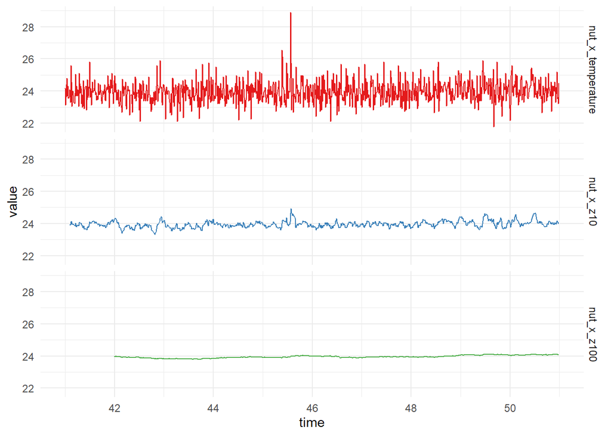

# Tile vs slide functions.

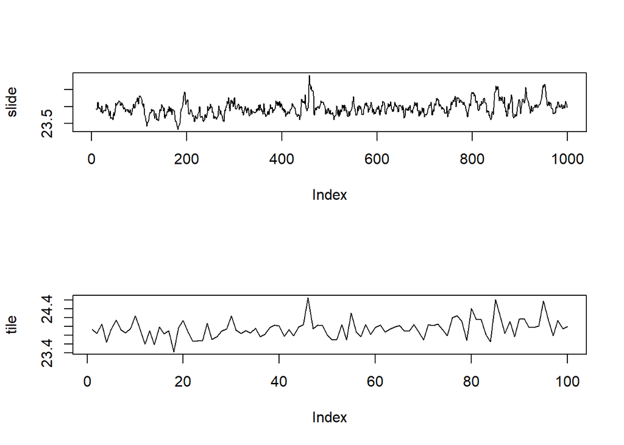

# Visualizing time series

The `autoplot` method of ggplot can visualize a time series using `ggplot2` methods. Because it is built on top of `ggplot2,` we can use our ggplot modifiers, like changing axis labels, titles, and themes.

For many of the functions in forecast, we need to use ts objects. Tsibble objects sometimes work, but we’ll concentrate on ts for now.

> Note: the team behind `forecast` is working on a tidy forecasting package called [`fable,`](https://github.com/tidyverts/fable) but at the time of writing it seems not quite ready, so we’ll save that for a future lesson.

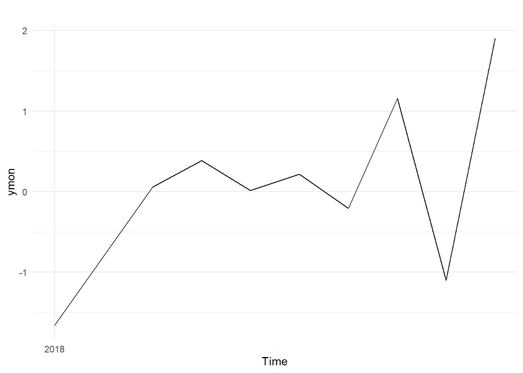

```r
library(forecast)
library(ggplot2)
autoplot(ymon)+theme_minimal()
```

# Trends, seasons, cycles

Time series can be composed of trends, seasonality or cycles, and we can separate these components.

- **Trend:** long-term increase or decrease, not necessarily linear.
- **Seasonality:** an effect by time of year or day of week, of a fixed and known frequency.
- **Cycles:** rises and falls that are not of a fixed frequency.
  - in general, cycle length is greater that seasonal length
  - magnitudes of cycles tend to be larger than seasonal patterns

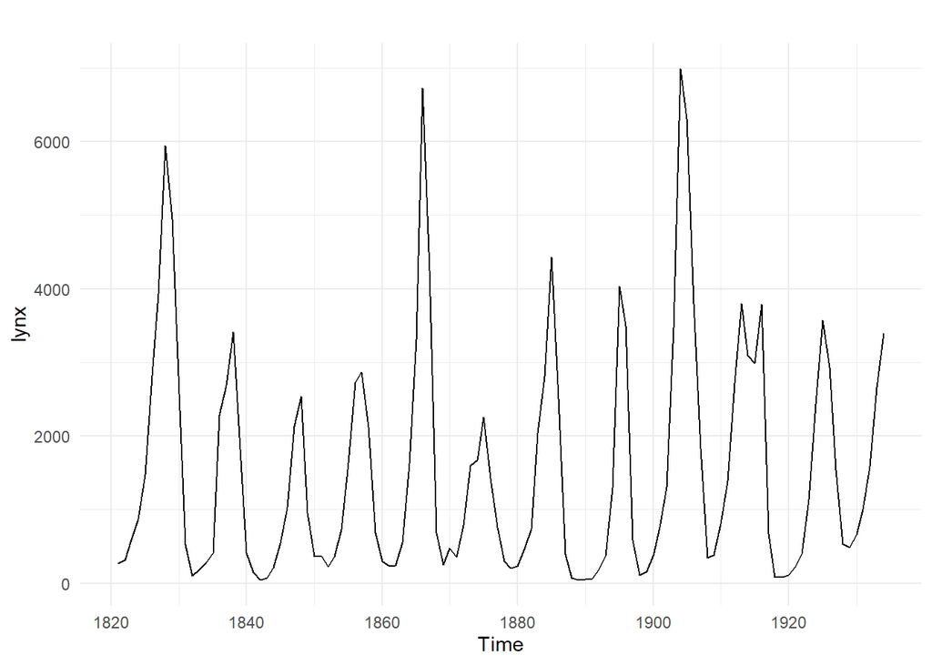

```r
# showing a cyclic pattern
autoplot(lynx) + theme_minimal()
```

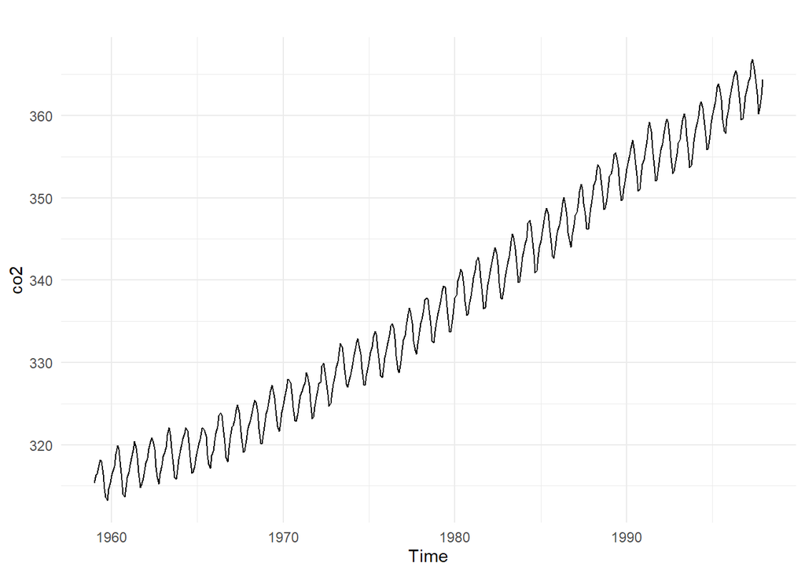

```r
# does the release of co2 from Mauna Loa have a  pattern?
autoplot(co2) + theme_minimal()
```